# Prob 4, CP 3

Author

2 de agosto de 2017

```r
#bibliotecas
library(tidyverse, quietly = TRUE)
library(dplyr, quietly = TRUE)
library(ggplot2)
library(tidyverse, quietly = TRUE)
library(resample, quietly = TRUE)
library(GGally, quietly = TRUE)
library(gridExtra, quietly = TRUE)
theme_set(theme_bw())
```

# Dados

Os dados analisados são referentes aos commits realizados no Github. Precisamos analisar as linguagens de programação com base na extensão dos arquivos commitados e responder as perguntas que foram construídas durante o checkpoint anterior.

```r
#dados
github_data <- read.csv("https://raw.githubusercontent.com/nazareno/fpcc2/master/datasets/github-users-committing-filetypes.csv")
#glimpse(github_data)

github_data %>%
  group_by(file_extension) %>%
  count(.)
```

```
## # A tibble: 42 x 2
## # Groups:   file_extension [42]
##    file_extension     n
##            <fctr> <int>
##  1              c   493
##  2             cc    15
##  3         config     5
##  4            cpp   496
##  5             cs   493
##  6         csproj   366
##  7            css   496
##  8            eot    50
##  9            gif    18
## 10             go   442
## # ... with 32 more rows
```

Inicialmente vamos escolher uma linguagem para ser a base de nossa análise e então iremos filtrar e modificar os dados para que eles possam ser mais fáceis de serem manipulados e responderem as nossas pergunta.

```r
#informações de data e dia da semana
github_data <- github_data %>%
  mutate(date = paste(the_year,the_month,month_day,sep='-') %>% as.Date(.))

github_data$weekday <- weekdays(as.Date(github_data$date))

github_data <- github_data %>%
  mutate(is_weekend = ifelse(weekday %in% c("sábado","domingo"),TRUE,FALSE))
```

# Primeira pergunta

- *Para uma determinada linguagem, há diferença significativa entre a estatística de popularidade que ela apresenta durante o final/início de ano e os fins de semana?*

```r
dados_go <- github_data %>% filter(file_extension %in% "go")

go_ferias <- dados_go %>%
  filter(the_month %in% c(1, 12)) %>%
  select(-month_day,-the_month,-the_year) %>%
  arrange(date)

go_anual <- dados_go %>%
  filter(!the_month %in% c(1, 12)) %>%
  select(-month_day,-the_month,-the_year) %>%
  arrange(date)
```

Observaremos a distribuição dos dados de modo a entender melhor o comportamento dos dados, segundo os gráficos abaixo:

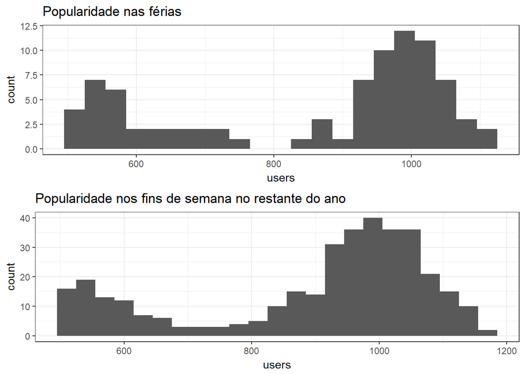

```r
# go_ferias %>% ggplot(aes(users)) + geom_histogram(binwidth = 25)
# go_anual %>% ggplot(aes(users)) + geom_histogram(binwidth = 25)
g1 <- go_ferias %>%
  ggplot(aes(users)) +
  geom_histogram(binwidth = 30) +
  labs(title = "Popularidade nas férias")
g2 <- go_anual %>%
  ggplot(aes(users)) +
  geom_histogram(binwidth = 30) +
  labs(title = "Popularidade nos fins de semana no restante do ano")
grid.arrange(g1,g2)
```

Definiremos a estatística da popularidade como sendo a mediana do número de usuários, porque com a mediana de um dado valor podemos representar bem os dados, já que 50% dos usuários observados utilizaram a linguagem para um determinado valor. Com isso, realizaremos as reamostragens com a utilização do bootstrap.

```r
amostra_ferias <- sample_n(go_ferias, 80)
amostra_ferias <- rename(amostra_ferias,users_ferias = users)

amostra_anual <- sample_n(go_anual, 80)
amostra_anual <- rename(amostra_anual,users_anual = users)

b <- bootstrap(amostra_ferias, median(users_ferias))
mediana_g1 <- CI.bca(b, probs = c(.025, .975))
mediana_g1
```

```
##                      2.5% 97.5%
## median(users_ferias)  898   978
```

```r
b <- bootstrap(amostra_anual, median(users_anual))
mediana_g2 <- CI.bca(b, probs = c(.025, .975))
mediana_g2
```

```
##                      2.5% 97.5%
## median(users_anual) 932.5   999
```

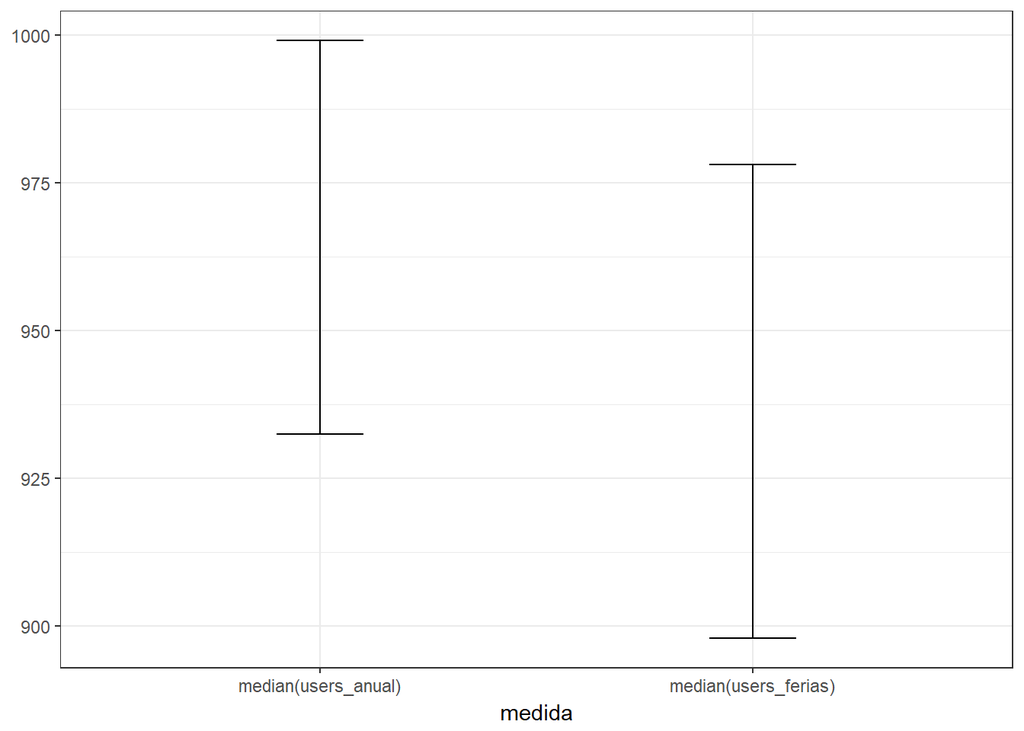

```r
df <- data.frame(rbind(mediana_g1,
                      mediana_g2))
df$medida = row.names(df)
df %>%
  ggplot(aes(x = medida, ymin = X2.5., ymax = X97.5.)) +
  geom_errorbar(width = .2)
```

Como os intervalos se interceptam, iremos analisar a diferença das estatísticas de modo a conseguir uma abordagem que possa atender melhor a pergunta. O resultado da diferença entre as estatísticas foi:

```r
b.diff.means <- bootstrap2(data = amostra_anual$users_anual, data2 =  amostra_ferias$users_ferias,
                          median)

means.diff = CI.percentile(b.diff.means, probs = c(.05, .95))
means.diff
```

```
##                       5% 95%
## median: data-data2 -25.5  45
```

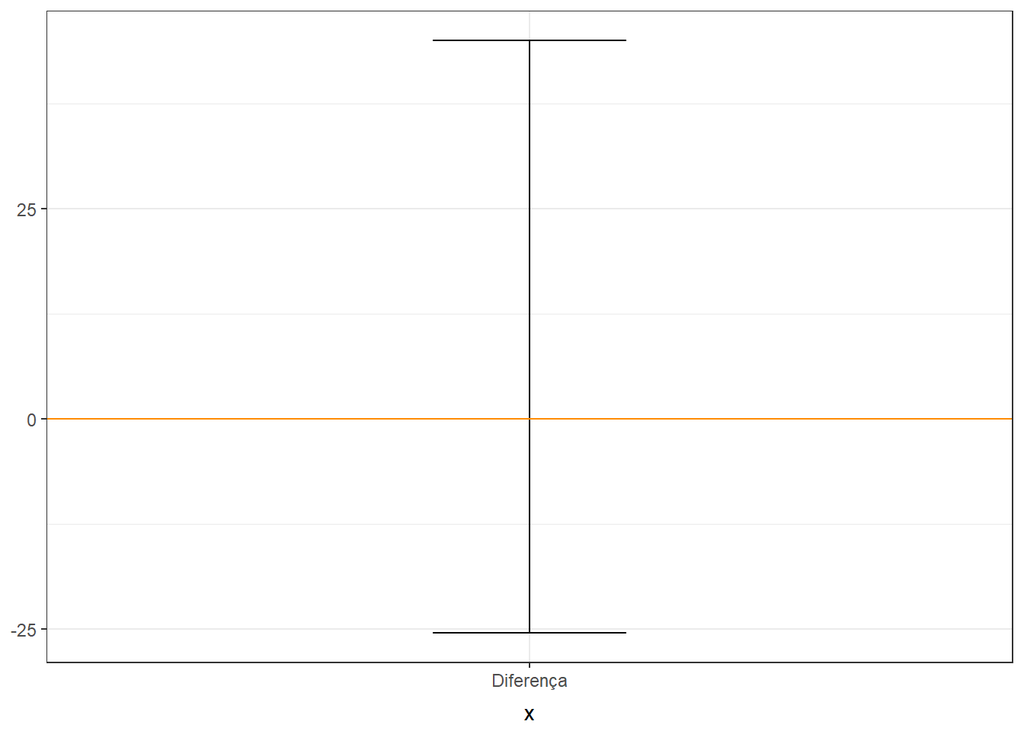

```r
data.frame(means.diff) %>%
  ggplot(aes(x = "Diferença", ymin = X5., ymax = X95.)) +
  geom_errorbar(width = .2) +
  geom_hline(yintercept = 0, colour = "darkorange")
```

Esse novo intervalo apresenta valores positivos e negativos. Com isso, não podemos inferir se há uma diferença significativa sobre a popularidade da linguagem durante as férias e durante o restante do ano. Isso nos indica que pode haver alguma relação entre as estatísticas, mas com muita incerteza.

## Novos Questionamentos

Com base nos resultados obtidos, não temos muita certeza sobre nossa inferência. No entanto, podemos fazer o questionamento se essa linguagem é uma linguagem mais casual ou comercial, por exemplo. Para isso podemos analisar a diferença entre a popularidade dos dias de semana e os fins de semana comerciais. Para isso, faremos algo parecido com o que já fizemos anteriormente.

[figure not shown]

```r
go_semana <- dados_go %>%
  filter(is_weekend == FALSE)
go_fds <- dados_go %>%
  filter(is_weekend == TRUE)


amostra_semana <- sample_n(go_semana, 100)
amostra_semana <- rename(amostra_semana,users_semana = users)

amostra_fds <- sample_n(go_anual, 100)
amostra_fds <- rename(amostra_fds,users_fds = users)

b <- bootstrap(amostra_semana, median(users_semana))
mediana_g1 <- CI.bca(b, probs = c(.025, .975))
#mediana_g1
b <- bootstrap(amostra_fds, median(users_fds))
mediana_g2 <- CI.bca(b, probs = c(.025, .975))
#mediana_g2

df <- data.frame(rbind(mediana_g1,
                      mediana_g2))
df$medida = row.names(df)
df %>%
  ggplot(aes(x = medida, ymin = X2.5., ymax = X97.5.)) +
  geom_errorbar(width = .2)
```

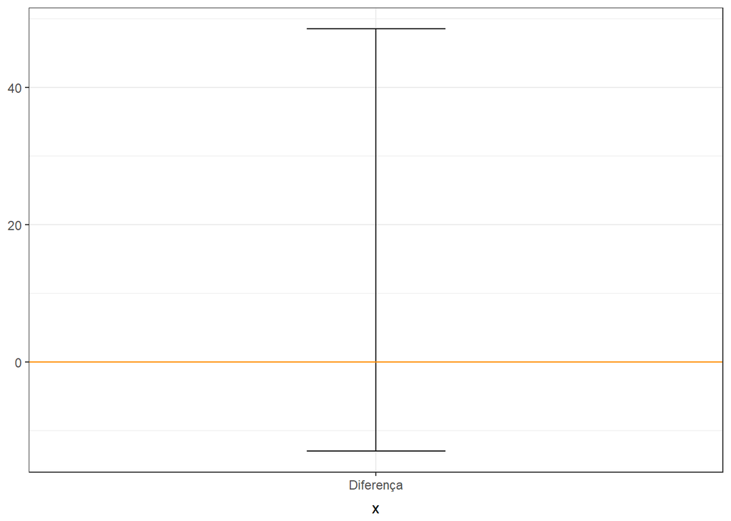

```r
b.diff.means <- bootstrap2(data = amostra_semana$users_semana, data2 =  amostra_fds$users_fds,
                          median)

means.diff = CI.percentile(b.diff.means, probs = c(.05, .95))
#means.diff

data.frame(means.diff) %>%
  ggplot(aes(x = "Diferença", ymin = X5., ymax = X95.)) +
  geom_errorbar(width = .2) +
  geom_hline(yintercept = 0, colour = "darkorange")
```

# Segunda pergunta

- *Há uma diferença significativa entre a popularidade de js e html?*

Inicialmente iremos selecionar os dados que serão necessários para responder a nossa pergunta. Queremos selecionar dois tipos de dados para trabalhar, respectivamente para os arquivos `js` e `html`. Esperamos observar que não haja uma diferença significativa, visto que essas duas linguagens são amplamente utilizadas em conjunto.

```r
dados_js <- github_data %>% filter(file_extension %in% "js") %>% select(-month_day,-the_month,-the_year) %>% arrange(date)
#dados_js

dados_html <- github_data %>% filter(file_extension %in% "html") %>% select(-month_day,-the_month,-the_year) %>% arrange(date)
#dados_html
```

Observando a distribuição dos dados temos:

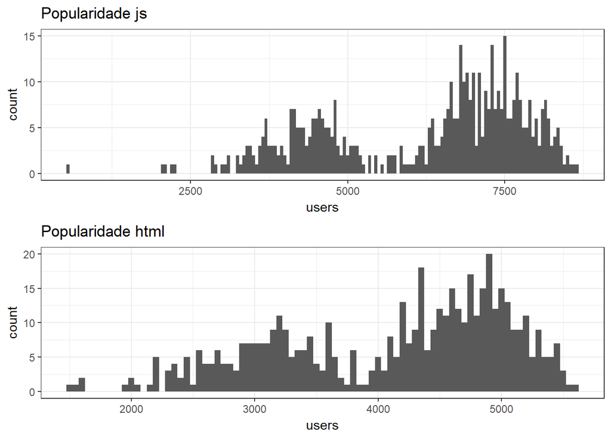

```r
js.plot <- dados_js %>%
  ggplot(aes(users)) +
  geom_histogram(binwidth = 50) +
  labs(title = "Popularidade js")
html.plot <- dados_html %>%
  ggplot(aes(users)) +
  geom_histogram(binwidth = 50) +
  labs(title = "Popularidade html")
grid.arrange(js.plot,html.plot)
```

```r
amostra_js <- sample_n(dados_js, 100)
amostra_js <- rename(dados_js,users_js = users)

amostra_html <- sample_n(dados_html, 100)
amostra_html <- rename(dados_html,users_html = users)

b <- bootstrap(amostra_js, median(users_js))
media_js <- CI.bca(b, probs = c(.025, .975))
media_js
```

```
##                  2.5% 97.5%
## median(users_js) 6639  6876
```

```r
b <- bootstrap(amostra_html, median(users_html))
media_html <- CI.bca(b, probs = c(.025, .975))
media_html
```

```
##                    2.5%  97.5%
## median(users_html) 4262 4478.5
```

Analisando graficamente os intervalos de confiança obtidos:

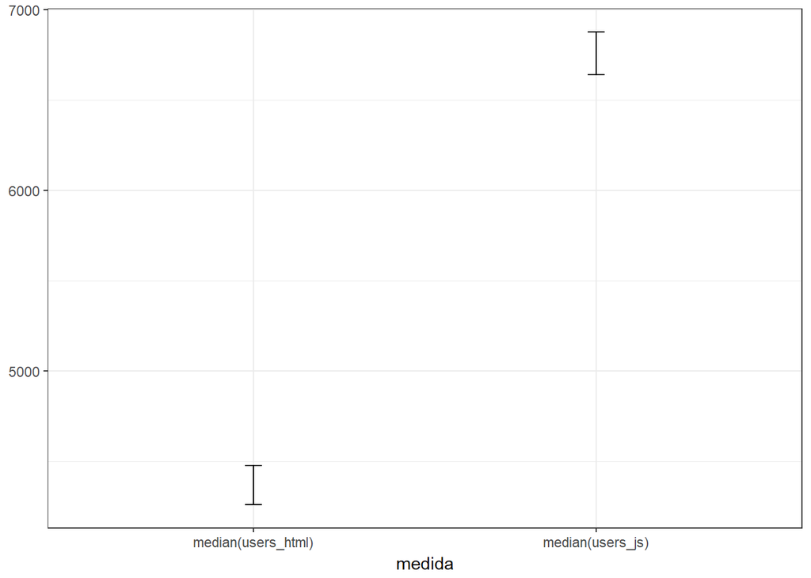

```r
df <- data.frame(rbind(media_js,
                      media_html))
df$medida = row.names(df)
df %>%
  ggplot(aes(x = medida, ymin = X2.5., ymax = X97.5.)) +
  geom_errorbar(width = .05)
```

Vemos que os intervalos estão distantes um do outro, o que nos mostra que a popularidade entre as linguagens é significativamente difente. Vemos que javascript é muito mais utilizada do que o html, nos mostrando que os arquivos .js dos repositórios do GitHub estão sendo utilizados para diversas aplicações, indo além da aplicação unicamente com o html.